# Natural Language Processing with Disaster Tweets

Sajjad

3/21/2021

# 1 Introduction

This Rmarkdown document describe my beginner attempt at Natural Language Processing using R. The dataset is obtained from [this Kaggle competition](https://www.kaggle.com/competitions/nlp-getting-started/data).

Each sample in the train and test set has the following information:

- The `text` of a tweet
- A `keyword` from that tweet (although this may be blank!)
- The `location` the tweet was sent from (may also be blank)

Twitter has become an important communication channel in times of emergency. The ubiquitousness of smartphones enables people to announce an emergency they’re observing in real-time. Because of this, more agencies are interested in programatically monitoring Twitter (i.e. disaster relief organizations and news agencies).

But, it’s not always clear whether a person’s words are actually announcing a disaster.

In this competition, you’re challenged to build a machine learning model that predicts which Tweets are about real disasters and which one’s aren’t. You’ll have access to a dataset of 10,000 tweets that were hand classified. If this is your first time working on an NLP problem, we’ve created a quick tutorial to get you up and running.

Disclaimer: The dataset for this competition contains text that may be considered profane, vulgar, or offensive.

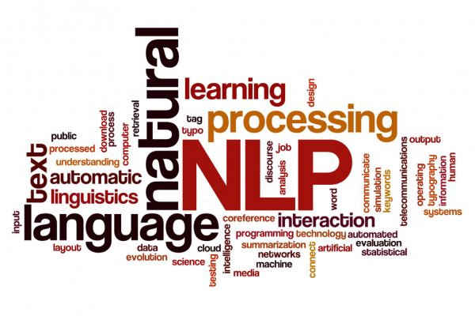

# 2 Missing values

```r
nMiss <- function(x) {sum(is.na(x))}

m <- as.data.frame(t(train %>% summarise_all(nMiss)))  %>%
  rownames_to_column() %>%
  rename(nMiss=V1, variable = rowname) %>%
  mutate(pMiss = paste0(round(nMiss/nrow(train) * 100, 2),"%")) %>%
  arrange(nMiss)

knitr::kable(m, col.names = c("Variable", "Number of Missing",
                              "Percentage of Missing (%)"), align = "c")
```

| Variable | Number of Missing | Percentage of Missing (%) |
| --- | --- | --- |
| id | 0 | 0% |
| text | 0 | 0% |
| target | 0 | 0% |
| keyword | 61 | 0.8% |
| location | 2534 | 33.29% |

# 3 Mislabelled records

Before proceeding with the analysis, I want to make sure there isn’t any mislabeled data (i.e., unique texts that are interpreted differently). These can be harmful to the model.

```r
duplicateLabel <- train %>%
  filter(duplicated(text)) %>%
  group_by(text) %>%
  mutate(mislabeled = if_else(!duplicated(target), 1, 0)) %>%
  ungroup() %>%
  filter(mislabeled == 1)
```

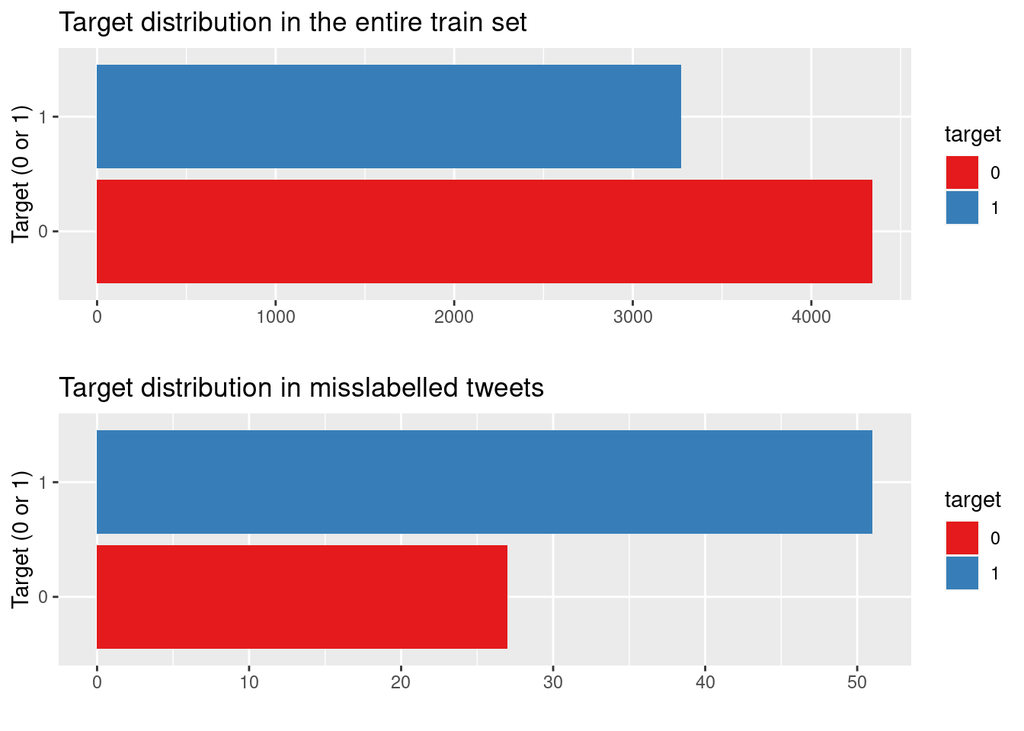

```r
a <- train %>%
  mutate(target = factor(target, levels = c(0, 1))) %>%
  ggplot(aes(x = target, fill = target)) +
  geom_bar()+
  scale_fill_brewer(palette = "Set1")+
  labs(x = "Target (0 or 1)", y = "",
       title = "Target distribution in the entire train set")+
  coord_flip()

b <- duplicateLabel %>%
  mutate(target = factor(target, levels = c(0, 1))) %>%
  ggplot(aes(x = target, fill = target)) +
  geom_bar()+
  scale_fill_brewer(palette = "Set1") +
  labs(x = "Target (0 or 1)", y = "",
       title = "Target distribution in misslabelled tweets")+
  coord_flip()

ggarrange(a, b,
          ncol = 1, nrow = 2, hjust = -.5, vjust = 2.5)
```

Looking at the plots, we realize there’s a considerable difference between the two groups. I would continue by removing these tweets from the training set as we really don’t have a way to find the correct labels.

```r
train <- train %>%
  filter(!(text %in% duplicateLabel$text))
```

# 4 Cleaning data

First, I’m Combining the two datasets to perform some cleaning. * note: it’s recommended to avoid any processing before splitting data. In this case I’m saving myself some time by processing train and test sets at the same time.

```r
x <- rbind(train%>%select(-target), test)
```

- Here’s a list of initial text cleaning operations to clean text column:
- removing “NA” from keyword
- replacing “%20% with” ”
- change all characters to lower
- replace any link address with “URL”
- creating flag variables for youtube, mentions
- stemming text
- and at the end, removing all blank spaces caused by previous operations.

```r
x <- x %>%
  mutate(keyword = str_replace_all(keyword, "NA", "")) %>%
  mutate(keyword = str_replace_all(keyword, "%20", " ")) %>%
  mutate(keyword = str_to_lower(keyword)) %>%
  mutate(text = str_to_lower(text)) %>%
  mutate(text = gsub("http[^[:space:]]*", "url", text)) %>%
  mutate(youTube = if_else(str_detect(text, "youtube"), 1, 0)) %>%
  mutate(mentions = if_else(str_detect(text, "@"), 1, 0)) %>%
  mutate(text = stemDocument(text, language = "english")) %>%
  mutate(text = str_trim(stripWhitespace(text)))
```

## 4.1 Location

It seems to me that location was free-texted by the users. This makes it difficult to interpret. Let’s first look at the distribution of target by whether a tweet has a location variable or not.

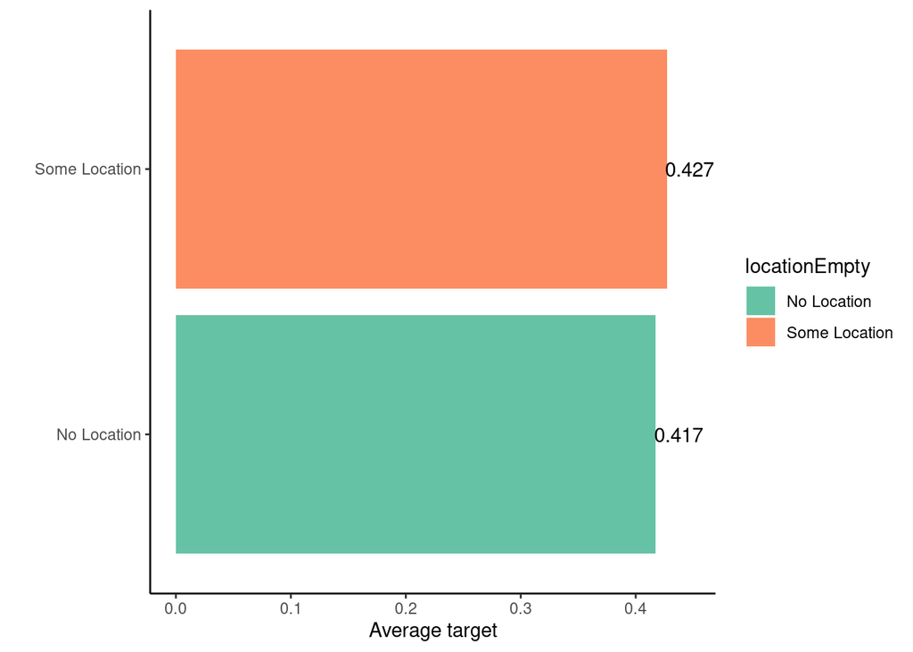

```r
train %>%
  mutate(locationEmpty = if_else(is.na(location), "No Location", "Some Location")) %>%
  mutate(target = as.numeric(target)) %>%
  group_by(locationEmpty) %>%
  summarise(n=mean(target)) %>%
  ggplot(aes(x=locationEmpty, y = n, fill = locationEmpty))+
  geom_bar(stat = "identity")+
  scale_fill_brewer(palette = "Set2")+
  geom_text(aes(x = locationEmpty, y = n+.02, label = round(n, 3)))+
  labs(x = "", y = "Average target")+
  coord_flip()+
  theme_classic()
```

I can see that there’s no significant difference between the the tweets with and without location. I’m gonna ignore location moving forward. If it was a real world project, I’d probably spend some time and clean location.

## 4.2 Keyword

Here I’ve checked to make sure if keyword is in the text of the tweet or not. If it’s not, I’ve added it to at the end to make sure we can use it in as an input to the model.

```r
# if a keyword is not mentioned in the text, add it to the text.
x <- x %>%
  mutate(text = if_else(!is.na(keyword) & !str_detect(text, keyword),
                        paste(text, keyword, sep = " "),
                        text))
```

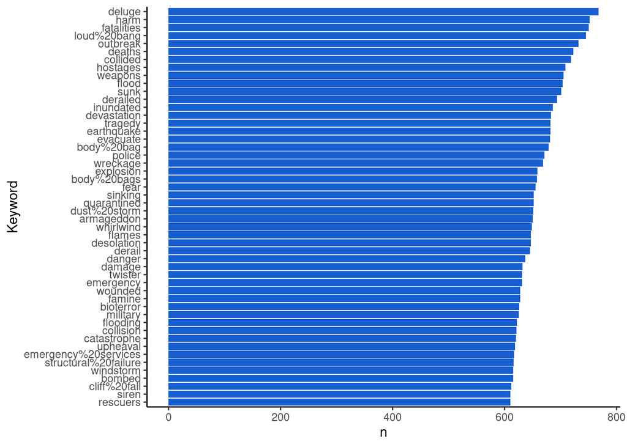

```r
train %>%
  unnest_tokens(word, text, strip_punct = T) %>%
  filter(!is.na(keyword)) %>%
  mutate(keyword = as.factor(keyword)) %>%
  group_by(keyword) %>%
  summarise(n = n()) %>%
  arrange(desc(n)) %>%
  filter(row_number() <= 50) %>%
  ggplot(aes(x = reorder(keyword, n), y = n))+
    geom_bar(stat = "identity", fill = "#175ed1")+
  labs(x="Keyword", y="n")+
  theme_classic()+
  coord_flip()
```

## 4.3 Explanation mark

I’m curious to know if tweets that have ! are more likely to be related to a disaster. Let’s just see:

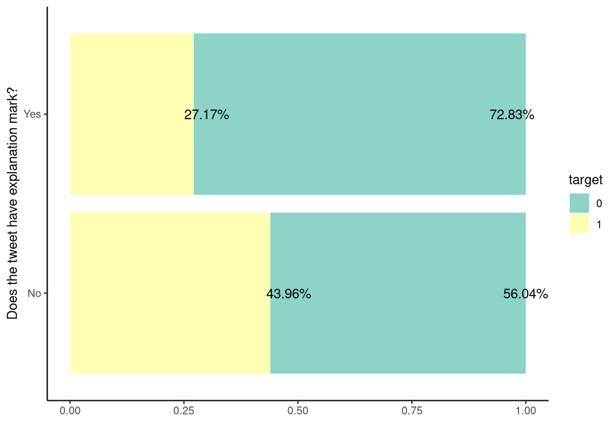

```r
aux <- train %>%
  mutate(expMark = if_else(str_detect(text, "!"), "Yes", "No")) %>%
  group_by(expMark) %>%
  summarise(groupN = n())

train %>%
  mutate(expMark = if_else(str_detect(text, "!"), "Yes", "No")) %>%
  mutate(target = as.factor(target)) %>%
  mutate(expMark = as.factor(expMark)) %>%
  group_by(expMark, target) %>%
  summarise(n = n()) %>%
  left_join(aux, by = c("expMark" = "expMark"))%>%
  ggplot(aes(x = expMark, y=n, fill = target))+
  geom_bar(position="fill", stat="identity")+
  scale_fill_brewer(palette = "Set3")+
  geom_text(aes(x = expMark, y= c(1, 0.48, 0.97, 0.3),
                label = paste0(round(n/groupN * 100, 2), "%")))+
  theme_classic()+
  labs(x = "Does the tweet have explanation mark?", y="")+
  coord_flip()
```

Actually it’s quite the opposite :) but we can still add explanation mark as a feature:

```r
x <- x %>%
  mutate(expMark = if_else(str_detect(text, "!"), 1, 0))
```

## 4.4 Digits

I’m also curious to know if tweets that have digits in them are more likely to be related to a disaster. In particular *911* and other emergency services in other countries can be a reason for this.

```r
train %>%
  mutate(digit = str_count(text, "[:digit:]")) %>%
  group_by(as.factor(target)) %>%
  summarise(n=mean(digit))
```

```
## # A tibble: 2 × 2
##   `as.factor(target)`     n
##   <fct>               <dbl>
## 1 0                    1.60
## 2 1                    2.64
```

this is a good signal to include number of digits as a feature too.

```r
x <- x %>%
  mutate(numDigits = str_count(text, "[:digit:]"))
```

# 5 Exploratory Data Analysis and Adding Features.

I suspect length of a tweet and number of strings used in a it can have some correlation with disasters, maybe people tend to use fewer words and/or longer/shorter words when tweeting about a disaster.

```r
x <- x %>%
  mutate(numStrings = str_count(text),
         numWords = str_count(text, '\\w+'))
```

## 5.1 Remove punctuations

```r
x <- x %>%
  mutate(text = removePunctuation(text),
         text = str_trim(stripWhitespace(text)))
```

## 5.2 Tokenize the dataset

```r
x <- x %>% unnest_tokens(word, text, strip_punct = T)
```

## 5.3 Abbreviations and contraactions

I used lists of abbreviations and contractions from some friends who were very kind and shared those with us on Kaggle. I put them in a separate file (dataCleaning.Rmd) to keep this one cleaner.

```r
x <- x %>%
  left_join(abbreviations, by=c("word" = "abb"))

x <- x %>%
  mutate(word = if_else(!is.na(allWords), allWords, word)) %>%
  unnest_tokens(word, word)
```

```r
x <- x %>%
  left_join(contractions, by=c("word" = "contraction"))

x <- x %>%
  mutate(word = if_else(!is.na(meaning), meaning, word)) %>%
  unnest_tokens(word, word)
```

## 5.4 Removing stopwords

I used tidytext *stop_words* dataset to remove all stop words from our training set.

```r
x <- x %>%
  anti_join(stop_words, by=c("word" = "word"))
```

## 5.5 Some Further Cleaning and Processing

```r
x <- x %>%
  group_by(id) %>%
  mutate(sentence = paste0(word, collapse =" ")) %>%
  mutate(keyword = if_else(word %in% unique(x$keyword) & is.na(keyword),
                           word, keyword))
```

## 5.6 Sentiments

I used tidytext’s sentiment dataset and added them (negative or positive) at the end of each tweet.

```r
# add sentiment as a word to the end of the sentence
x <- x %>%
  left_join(get_sentiments(), by= c("word" = "word")) %>%
  mutate(sentence = if_else(!is.na(sentiment),
                            paste(sentence, sentiment, " "), sentence))
```

## 5.7 Words Frequency

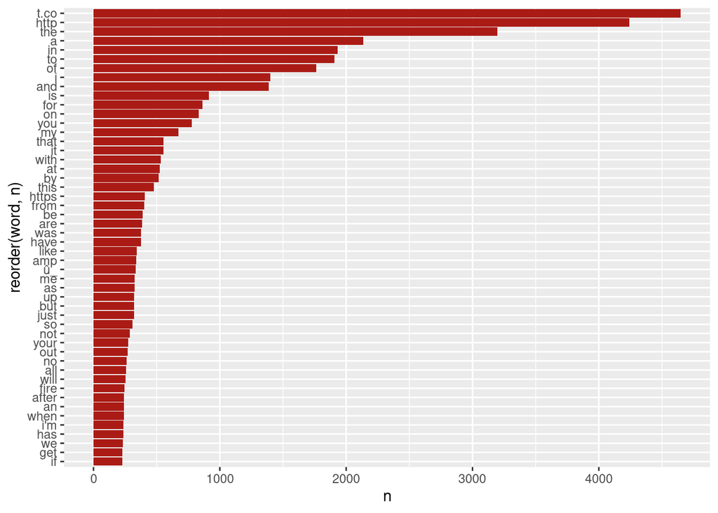

```r
train %>%
  unnest_tokens(word, text, strip_punct = T) %>%
  group_by(word) %>%
  summarise(n=n()) %>%
  arrange(desc(n)) %>%
  filter(row_number() <= 50) %>%
  ggplot(aes(x = reorder(word, n), y = n))+
    geom_bar(stat = "identity", fill = "#ab1b16")+
  coord_flip()
```

- Some more insights from the tokenized data: +remove digits +remove special characters +remove < 10 and > 300 +remove t.co and http

```r
x <- x %>%
  filter(!(str_detect(word, "[:digit:]")) & str_detect(word, "[:alpha:]")) %>%
  mutate(word = str_replace_all(word, "û", " ")) %>%
  mutate(word = str_replace_all(word, "ª", " ")) %>%
  mutate(word = str_replace_all(word, "ï", " ")) %>%
  mutate(word = str_replace_all(word, "ó", " ")) %>%
  mutate(word = str_replace_all(word, "å", " ")) %>%
  mutate(word = str_replace_all(word, "ã", " ")) %>%
  mutate(word = str_replace_all(word, "à", " ")) %>%
  mutate(word = str_replace_all(word, "ê", " ")) %>%
  mutate(word = str_replace_all(word, "â", " ")) %>%
  mutate(word = str_replace_all(word, "ò", " ")) %>%
  mutate(word = str_replace_all(word, "á", " ")) %>%
  mutate(word = str_replace_all(word, "http", " ")) %>%
  mutate(word = str_replace_all(word, "t.co", " ")) %>%
  mutate(word = str_trim(stripWhitespace(word))) %>%

  filter(word != "" & word != " " & word != "  " &
         word != "i am" & word != "we are" & word != "they are",
         word != "he is" & word != "she is" & word != "we are not")
```

Now let’s move back the train and test datasets.

```r
xTrain <- x %>%
  filter(!duplicated(id)) %>%
  select(id, youTube, mentions, numStrings, numWords, expMark, numDigits,
         sentence) %>%
  right_join(train %>% select(id, keyword, location, target), by = "id") %>%
  mutate(location = as.factor(location), keyword = as.factor(keyword)) %>%
  mutate(youTube = as.integer(youTube), mentions = as.integer(mentions),
         expMark = as.integer(expMark)) %>%
  rename(text = sentence) %>%
  filter(!is.na(text))
```

```r
xTest <- x %>%
  filter(!duplicated(id)) %>%
  select(id, youTube, mentions, numStrings, numWords, expMark, numDigits,
         sentence) %>%
  right_join(test %>% select(id, keyword, location), by = "id") %>%
  mutate(location = as.factor(location), keyword = as.factor(keyword)) %>%
  mutate(youTube = as.integer(youTube), mentions = as.integer(mentions),
         expMark = as.integer(expMark)) %>%
  rename(text = sentence) %>%
  filter(!is.na(text))
```

## 5.8 Effect Evaluation Using Logistic Regression

- To see the possible association between number of strings, number of words, mentions, and youTube links. This is more of an effect size model not a predictor.

```r
lrModel <- glm(target ~ youTube + mentions + numStrings + numWords + expMark +
                 numDigits,
               data = xTrain, family="binomial")

summary(lrModel)
```

```
##
## Call:
## glm(formula = target ~ youTube + mentions + numStrings + numWords +
##     expMark + numDigits, family = "binomial", data = xTrain)
##
## Deviance Residuals:
##     Min       1Q   Median       3Q      Max
## -2.2901  -1.0130  -0.7582   1.1826   2.2308
##
## Coefficients:
##              Estimate Std. Error z value Pr(>|z|)
## (Intercept) -0.920512   0.076100 -12.096  < 2e-16 ***
## youTube     -0.491637   0.258898  -1.899   0.0576 .
## mentions    -0.766383   0.059731 -12.831  < 2e-16 ***
## numStrings   0.039320   0.002317  16.973  < 2e-16 ***
## numWords    -0.170844   0.011744 -14.547  < 2e-16 ***
## expMark     -0.727392   0.091838  -7.920 2.37e-15 ***
## numDigits    0.090071   0.011189   8.050 8.28e-16 ***
## ---
## Signif. codes:  0 '***' 0.001 '**' 0.01 '*' 0.05 '.' 0.1 ' ' 1
##
## (Dispersion parameter for binomial family taken to be 1)
##
##     Null deviance: 10129.8  on 7431  degrees of freedom
## Residual deviance:  9538.7  on 7425  degrees of freedom
## AIC: 9552.7
##
## Number of Fisher Scoring iterations: 4
```

# 6 Model Development and Anlysis

## 6.1 Text Vectorization

Let’s just quickly look at one document

```r
text_vectorization(matrix(xTrain$text[1995], ncol = 1))
```

```
## tf.Tensor(
## [[9418  901  655 4857 2513 8063  736 1270  218    0    0    0    0    0
##      0    0    0    0    0    0    0    0    0    0    0    0    0    0
##      0    0    0    0    0    0    0    0    0    0    0    0    0    0
##      0    0    0    0    0    0    0    0    0    0    0    0    0    0
##      0    0    0    0    0    0    0    0    0    0    0    0    0    0
##      0    0    0    0    0    0    0    0    0    0    0    0    0    0
##      0    0    0    0    0    0    0    0    0    0    0    0    0    0
##      0    0    0    0    0    0    0    0    0    0    0    0    0    0
##      0    0    0    0    0    0    0    0    0    0    0    0    0    0
##      0    0    0    0    0    0    0    0    0    0    0    0    0    0]], shape=(1, 140), dtype=int64)
```

## 6.2 Design Text Layer

```r
inputText <- layer_input(shape=c(1), dtype="string")

outputText <- inputText %>%
  text_vectorization() %>%
  layer_embedding(num_words, max_length) %>%
  layer_lstm(units=max_length) %>%
#  layer_global_average_pooling_1d() %>%
  layer_dense(units = 301, activation = "relu",
              kernel_regularizer = regularizer_l2(l = 0.001)) %>%
  layer_dropout(0.75)

textModel <- keras_model(inputText, outputText)
```

## 6.3 Design Features Layer

```r
otherLength <- ncol(xTrain[c("youTube", "mentions", "numStrings", "numWords",
                                      "numDigits", "expMark")])

inputOther <- layer_input(shape=c(otherLength),
                          dtype="int32", name="inputOther")
outputOther <-
  inputOther %>%
  layer_normalization() %>%
  layer_dense(unit=10, activation="relu",
              kernel_regularizer = regularizer_l1(l = 0.001))%>%
  layer_dropout(0.25)

otherModel <- keras_model(inputOther, outputOther)
```

## 6.4 Concatenating Layers

```r
concat <- k_concatenate(c(outputText, outputOther))
```

```r
finalOutput <- concat %>%
  layer_dense(units = 1, activation = "sigmoid")
```

## 6.5 Building the Model

```r
model <- keras_model(inputs = list(inputText, inputOther),
                     outputs = finalOutput)
```

```r
model %>% compile(
  optimizer = 'adam',
  loss = 'binary_crossentropy',
  metrics = list('accuracy')
)
```

## 6.6 Training the Model

```r
aux <-  as.matrix(xTrain[c("youTube", "mentions", "numStrings", "numWords",
                             "numDigits", "expMark")])
history <- model %>%
  keras::fit(
  list(xTrain$text, aux[1:7432, ]),
  xTrain$target,
  epochs = 10,
  batch_size = 250,
  validation_split = 0.2,
  verbose=2)
```

```r
summary(model)
```

```
## Model: "model_2"
## ________________________________________________________________________________
##  Layer (type)         Output Shape   Param #  Connected to           Trainable
## ================================================================================
##  input_1 (InputLayer)  [(None, 1)]   0        []                     Y
##  text_vectorization (  (None, 140)   0        ['input_1[0][0]']      Y
##  TextVectorization)
##  embedding (Embedding  (None, 140, 1  1303400  ['text_vectorization[  Y
##  )                    40)            0        0][0]']
##  inputOther (InputLay  [(None, 6)]   0        []                     Y
##  er)
##  lstm (LSTM)          (None, 140)    157360   ['embedding[0][0]']    Y
##  normalization (Norma  (None, 6)     13       ['inputOther[0][0]']   Y
##  lization)
##  dense (Dense)        (None, 301)    42441    ['lstm[0][0]']         Y
##  dense_1 (Dense)      (None, 10)     70       ['normalization[0][0]  Y
##                                               ']
##  dropout (Dropout)    (None, 301)    0        ['dense[0][0]']        Y
##  dropout_1 (Dropout)  (None, 10)     0        ['dense_1[0][0]']      Y
##  tf.concat (TFOpLambd  (None, 311)   0        ['dropout[0][0]',      Y
##  a)                                            'dropout_1[0][0]']
##  dense_2 (Dense)      (None, 1)      312      ['tf.concat[0][0]']    Y
## ================================================================================
## Total params: 13,234,196
## Trainable params: 13,234,183
## Non-trainable params: 13
## ________________________________________________________________________________
```

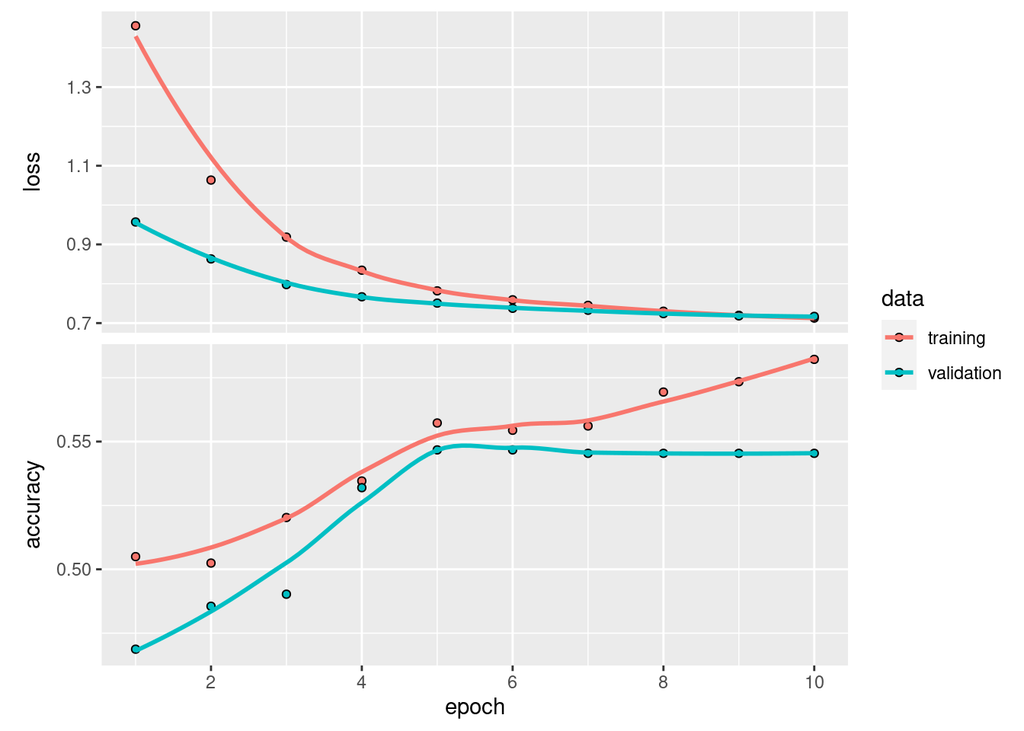

```r
plot(history)
```

# 7 Predict the test set

```r
aux <-  as.matrix(xTest[c("youTube", "mentions", "numStrings", "numWords",
                             "numDigits", "expMark")])
predictions <- model %>% predict(list(xTest$text,aux[1:nrow(xTest), ]))

submission <- xTest %>%
  select(id) %>%
  cbind(predictions[,1])

names(submission) = c("id", "probNN")

submission <- submission %>%
  rbind(tibble(id = 43, probNN = 0)) %>%
  mutate(target = if_else(probNN >= .50, 1, 0))
```

# 8 Export submission

```r
write_csv(submission%>%select(id, target), "submissionSajjad.csv")
```